# Assignment1

4.3.16

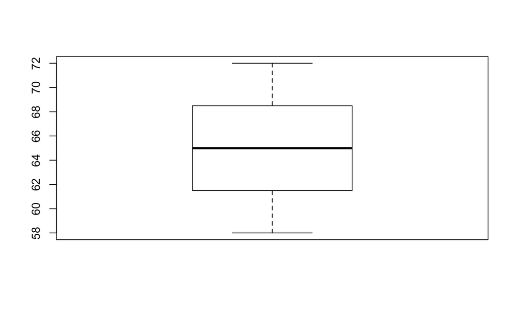

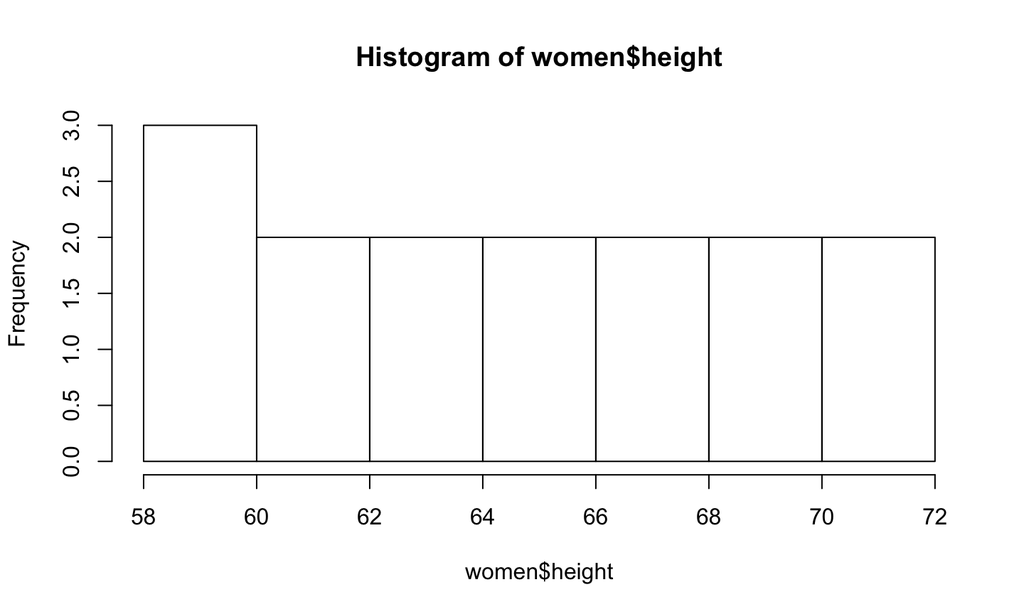

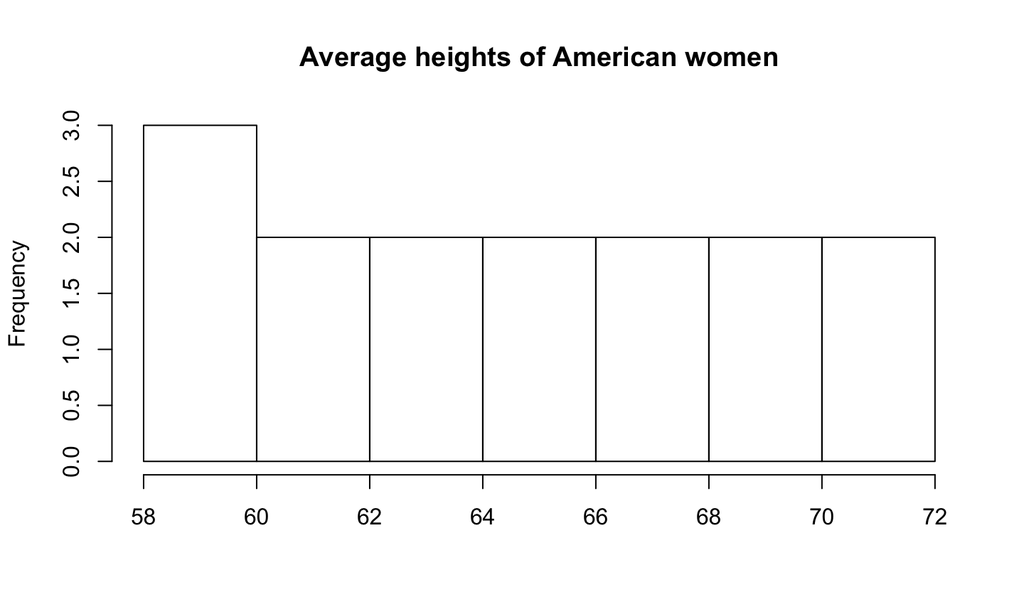

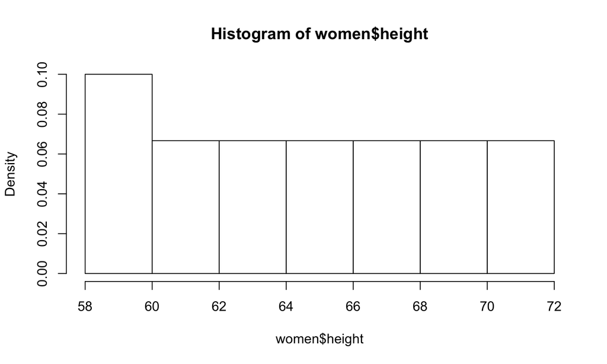

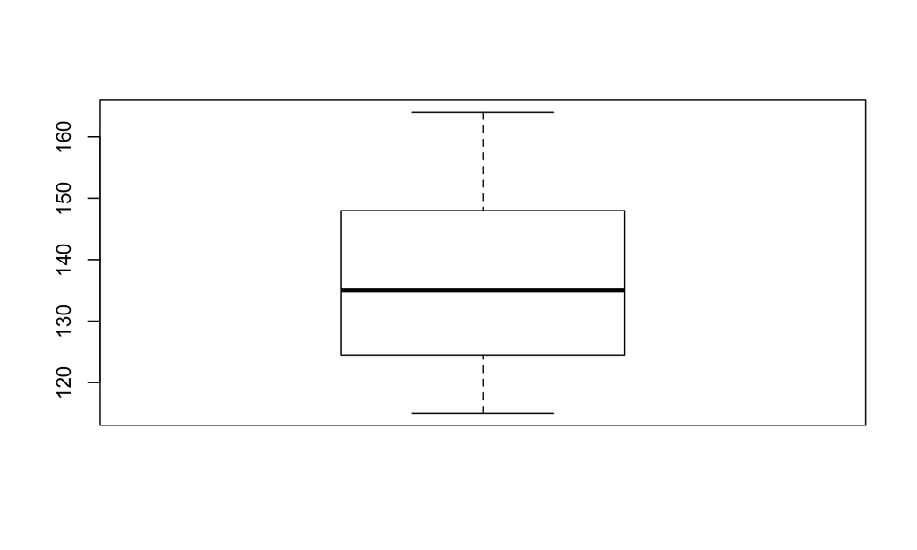

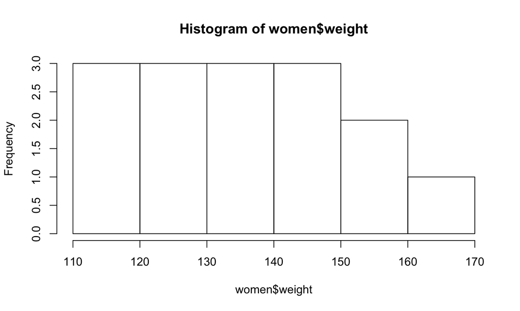

[figure not shown]

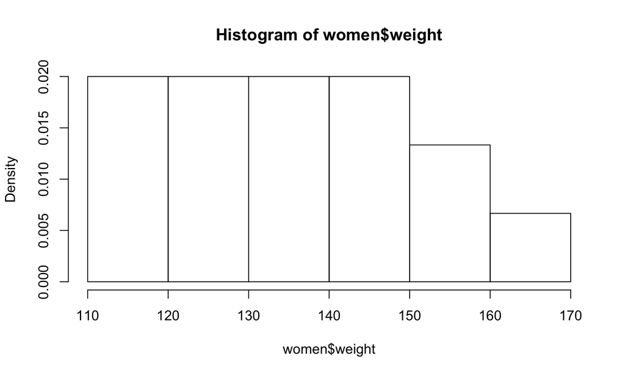

[figure not shown]

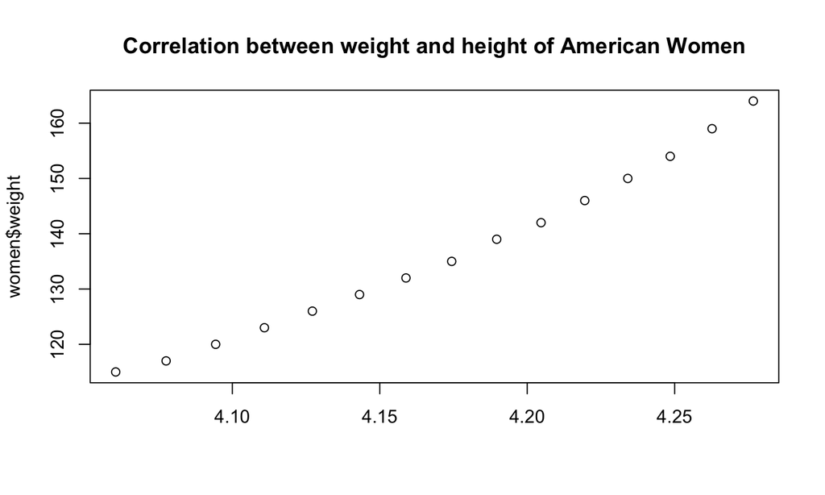

## Introduction

This presentations summarizes the main findings of two data sets:

- Average heights and weights for American women aged 30-39.
- Number of telephones in various regions of the world

## Slide with Plot

Using the box plots, we can see that the distribution os the two variables are reasonably symmetric, even though in the case of the variable 'weight', the distribution is concentrated between the 1st and the second quartile.

```r
str(women)
```

```
## 'data.frame':    15 obs. of  2 variables:
##  $ height: num  58 59 60 61 62 63 64 65 66 67 ...
##  $ weight: num  115 117 120 123 126 129 132 135 139 142 ...
```

## Women data set: plots

Using the box plots, we can see that the distribution of the two variables are reasonably symmetric, even though in the case of the variable 'weight', the distribution is concentrated between the 1st and the 2nd quartiles.

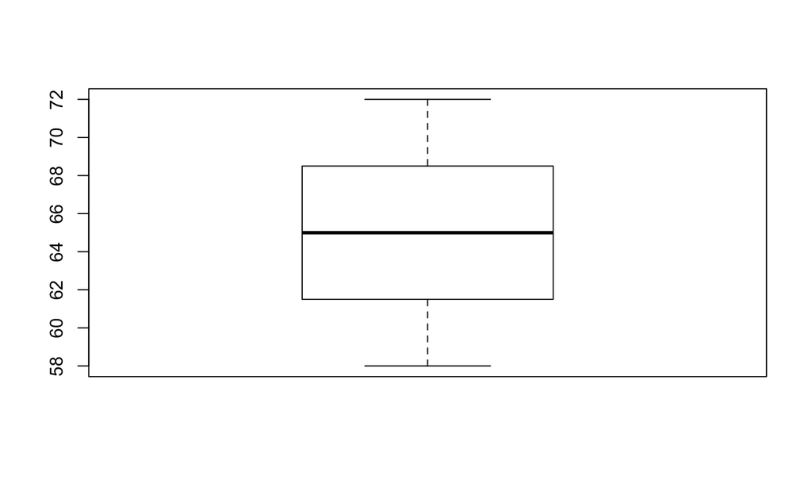

```r
boxplot(women$height)
```

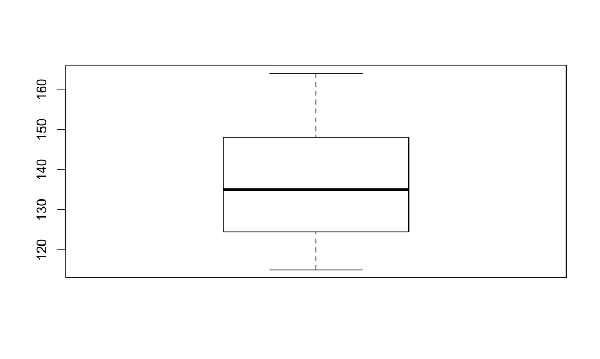

```r
boxplot(women$weight)
```

## Women data set: histograms

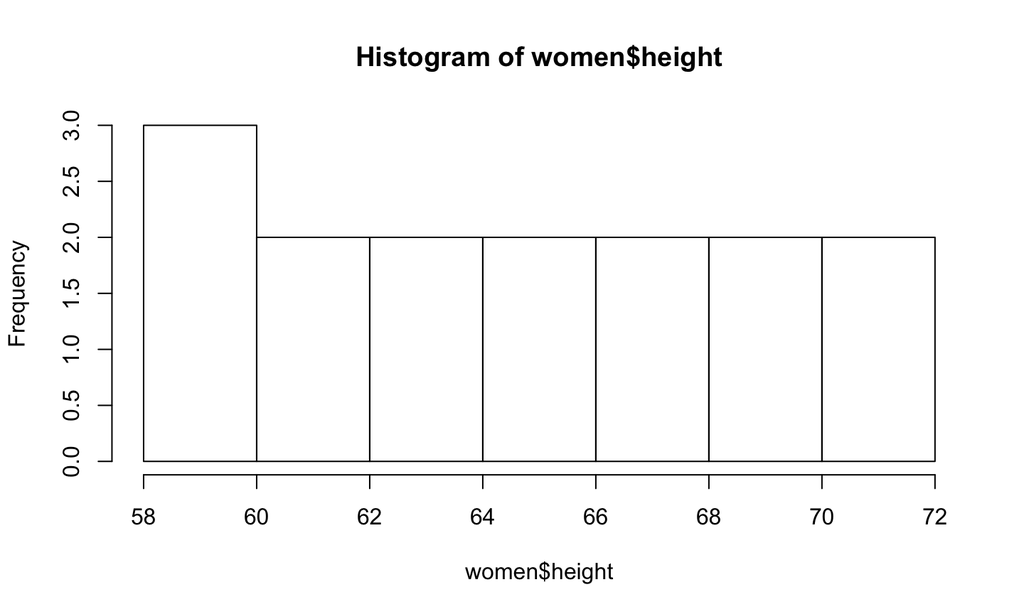

```r
hist(women$height)
```

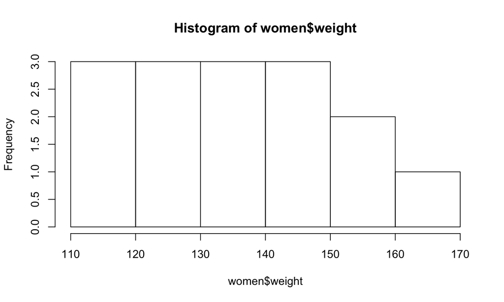

```r
hist(women$weight)
```

## Correlation of variables

Finally, the two variables are highly positively correlated, since correlation is 0.99. Positive correlation is showed by the correlation graph, when height increases, weight increases too.

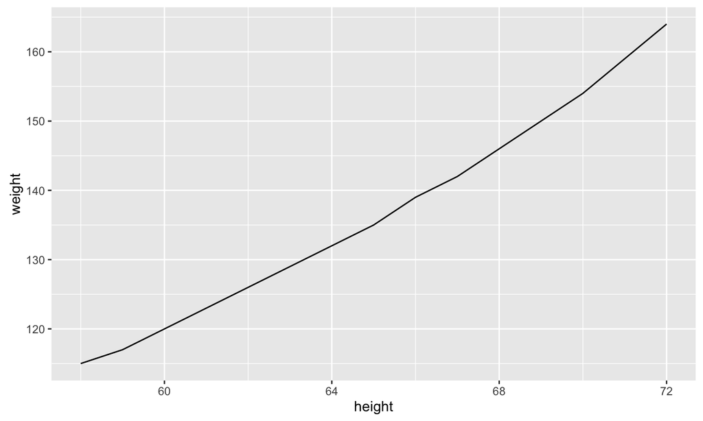

```r
ggplot(women, aes(height, weight)) + geom_path()
```

## Telephones

The datas set "The World's telephones" consists on:

- Number of telephones connections (in thousands)
- Region of the telephones' connections: North America, Europe, Asia, South America, Oceania, Africa, Central America.
- Years: 1951, 1956, 1957, 1958, 1959, 1960, 1961.

## Main findings

Mean, median and standar deviation

```
##      pho.mean pho.median   pho.sd
## [1,] 16434.76       3000 24026.33
## attr(,"names")
## [1] "Phones' mean"               "Phones' median"
## [3] "Phones' standard deviation"
```

[output not shown]

## Main findings

Mean, median and standar deviation

[output not shown]

## Graph1

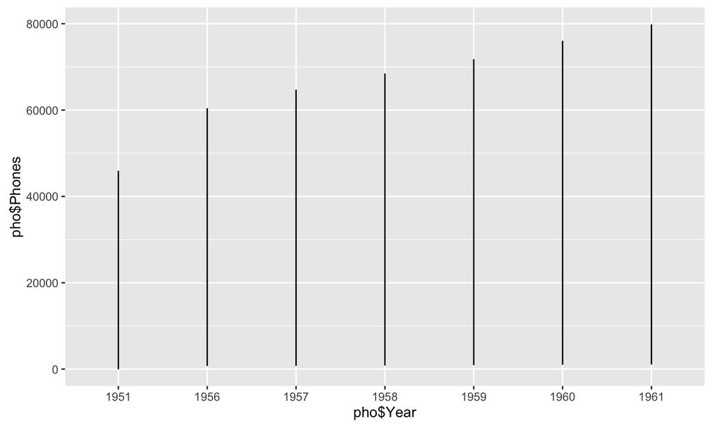

## Graph2

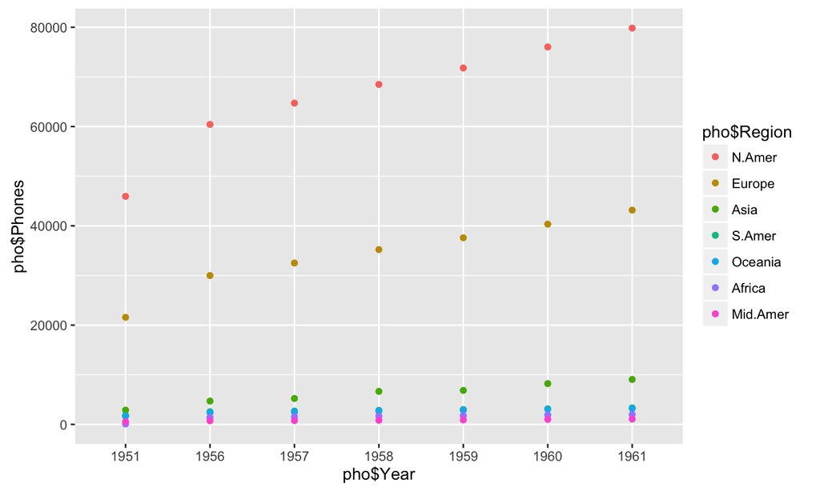